# Principal Component Aanalysis Response

# Part III

## Also in this repository is a data set collected from class that shows how many students thought that a TC program was related to another TC program. Use PCA to look for components of related programs. Explain why you think there are relationships between these programs.

*The underlying structure of the data is a square matrix of 68 programs x 68 programs. Each program is listed as a column name and in the column “program”. The numbers in the cells represent the number of people who said that the programs of the row and column which the cell is in are related. This includes the diagonals, instances where the row and column refer to the same program*

```r
#Read in space delimited data
TCprograms <- read_table2("TCprograms.csv")
```

```r
#Get rid of all those annoying dots and quotes
colnames(TCprograms) <- str_remove_all(string = colnames(TCprograms), pattern = '"') %>%
                          str_replace_all(pattern = "\\.", replacement = "_")
TCprograms$program <- str_remove_all(string = colnames(TCprograms), pattern = '"') %>%
                        str_replace_all(pattern = "\\.", replacement = "_")

#Remove program field, Remove program row
programs_only <- filter(TCprograms, program != "program")
programs_numbers_only <- select(programs_only, -program)

#Recode diagonals as 0?
#diag(programs_numbers_only) <- 0
```

[figure not shown]

```r
#Generate pairwise correlations
COR_programs <- cor(programs_numbers_only)

corrplot(COR_programs,
         order = "AOE",
         method = "circle",
         tl.pos = "lt",
         type = "lower",
         tl.col = "black",
         tl.cex = 0.5,
         tl.srt = 45,
         addCoef.col = "black",
         addCoefasPercent = TRUE,
         sig.level = 0.50, insig = "blank",
         number.cex = 0.1
         )
```

```r
#Then, scale and center your data for easier interpretation
programs_scaled <- scale(programs_numbers_only, center = TRUE)

#Fix diagonals to 1, because there should be full correspondence between something and itself. This is not reflected
#well in the data because not everyone got an option to select something on the diagonal.
diag(programs_scaled) <- 1
```

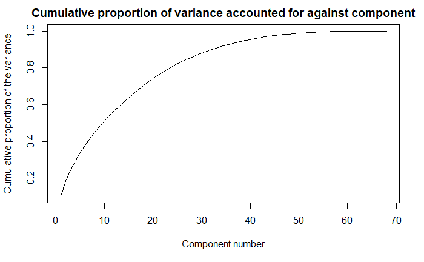

```r
#PCA
pca_programs <- prcomp(programs_scaled, scale = TRUE)

#A summary of our pca will give us the proportion of variance accounted for by each component
pca_programs_summary <- summary(pca_programs)

#Plot Cumulative proportion of variance accounted for against component
plot(pca_programs_summary$importance[3, ],
     type = "lines",
     main = "Cumulative proportion of variance accounted for against component",
     xlab = "Component number",
     ylab = "Cumulative proportion of the variance"
     )
```

```r
#Now, create a data frame of the transformed data from your pca.
pca_programs_df <- data.frame(pca_programs$x)
```

*What we want to do here is to get the loadings of each program on the PCs, then find which ones contribute the most/least to the PC.*

*It should be the case that programs with high loadings onto the same PC are ‘related programs’ since the same component captures a larger degree of variation in both/all these programs. The PC is then a ‘component of related programs’.*

*It is also worth looking at the programs with the lowest loadings onto the same PC as they’re likely ‘related programs’ insofar as the same component fails to capture much variation in these programs. The PC is then also a ‘component of related programs’*

```r
#Get original feature loadings on principal components
loadings_programs <- abs(pca_programs$rotation) #abs() will make all eigenvectors positive

#sweep() computes each row as a proportion of the column. (There must be a way to do this with dplyr()?)
loadings_programs_df <- as.data.frame(sweep(loadings_programs,
                                            2,
                                            colSums(loadings_programs),
                                            "/")
                                      )

#Define blank data frame
components_by_related_program <- data.frame(initialise = matrix(NA, nrow = 68, ncol = 1))

#Get the PC names to build a for loop
PCs <- colnames(loadings_programs_df)

#Add the program names as a column instead of rownames to stop them disappearing when using dplyr functions
loadings_programs_df <- rownames_to_column(loadings_programs_df, "programs")

#For loop to iterate through the PCs, sort them in descending order, and return the most highly weighted programs to append to our data frame
for (column in PCs) {
  sorted_programs <- arrange(loadings_programs_df, desc(!!sym(column)))
  components_by_related_program <- cbind(components_by_related_program, sorted_programs$programs, stringsAsFactors = FALSE)
}

#clean the output df
components_by_related_program <- components_by_related_program[, -1]
colnames(components_by_related_program) <- PCs
```

```r
components_by_related_program
```

| PC1 | PC2 | PC3 | PC4 | PC5 | PC6 | PC7 | PC8 | PC9 | PC10 | PC11 | PC12 | PC13 | PC14 | PC15 | PC16 | PC17 | PC18 | PC19 | PC20 | PC21 | PC22 | PC23 | PC24 | PC25 | PC26 | PC27 | PC28 | PC29 | PC30 | … |
| --- | --- | --- | --- | --- | --- | --- | --- | --- | --- | --- | --- | --- | --- | --- | --- | --- | --- | --- | --- | --- | --- | --- | --- | --- | --- | --- | --- | --- | --- | --- |
| Change_Leadership | Kinesiology | Cognitive_Science | Linguistics | History | Science_Education | Gifted_Education | Social_Studies | Curriculum_and_Teaching | Intellectual_Disability_Autism | Art_Education | Education_Technology | Leadership | Behavior_Analysis | Education_Leadership | Instructional_Technology_and_Media | Anthropology | Measurement__Evaluation_and_Statistics | Cognitive_Science | Physical_Education | Dance_Education | Movement_Science | Literacy | College_Advising | Creative_Technologies | Nursing | Motor_Learning_and_Control | Spirituality_Mind_Body | Measurement__Evaluation_and_Statistics | Nutrition | … |
| Economics_and_Education | Clinical_Psychology | Learning_Analytics | English_Education | Urban_Education | Higher_and_Postsecondary_Education | Communication_Sciences_and_Disorders | International_and_Comparative_Education | Developmental_Psychology | Philosophy | Curriculum_and_Teaching | Reading | Inclusive_Education | Inclusive_Education | Developmental_Psychology | Curriculum_and_Teaching | Art_Education | Anthropology | Creative_Technologies | Psychological_Counseling | Developmental_Psychology | English_Education | Psychology | Bilingual_Bicultural_Education | Reading | Movement_Science | Inclusive_Education | Cooperation_and_Conflict_Resolution | History | Physical_Education | … |
| School_Principals | Health_Education | Mathematics | Teaching_English | Higher_and_Postsecondary_Education | School_Psychology | Dance_Education | Urban_Education | Nutrition | Cooperation_and_Conflict_Resolution | Instructional_Technology_and_Media | College_Advising | Teaching_English | School_Psychology | Philosophy | Sexuality__Women_and_Gender_in_Psychology | Neuroscience | Mathematics | Science_Education | Sociology | Intellectual_Disability_Autism | Early_Childhood_Special_Education | Curriculum_and_Teaching | Sociology | Adult_Education | Psychology | Arts_Administration | Physiology | Linguistics | Instructional_Technology_and_Media | … |
| Education_Policy | Physiology | Measurement__Evaluation_and_Statistics | Deaf_and_Hard_of_Hearing | Dance_Education | Private_School_Leadership | Music | Literacy | School_Principals | Deaf_and_Hard_of_Hearing | College_Advising | Diabetes_Education | Music | Psychological_Counseling | Literacy | Nursing | Communication_Media_and_Learning_Technologies | Movement_Science | Behavior_Analysis | Reading | Mathematics | School_Principals | Inclusive_Education | Linguistics | Kinesiology | Higher_and_Postsecondary_Education | Adult_Education | Physical_Education | Kinesiology | Communication_Media_and_Learning_Technologies | … |
| Politics | Neuroscience | Design_and_Development_of_Digital_Games | cluster | Music | Measurement__Evaluation_and_Statistics | Education_Policy | Communication_Media_and_Learning_Technologies | Spirituality_Mind_Body | Behavior_Analysis | Learning_Analytics | Nutrition | Philosophy | Philosophy | Economics_and_Education | Early_Childhood_Education | School_Psychology | Diabetes_Education | Deaf_and_Hard_of_Hearing | Instructional_Technology_and_Media | Early_Childhood_Special_Education | Sociology | Design_and_Development_of_Digital_Games | Learning_Analytics | Cooperation_and_Conflict_Resolution | Teaching_English | History | Teaching_English | Cooperation_and_Conflict_Resolution | Higher_and_Postsecondary_Education | … |
| Social_Organizational_Psychology | Nursing | Instructional_Technology_and_Media | Literacy | Counseling_Psychology | Movement_Science | Early_Childhood_Education | Mathematics | Social_Organizational_Psychology | College_Advising | Intellectual_Disability_Autism | Movement_Science | Gifted_Education | Leadership | Physical_Education | Nutrition | Movement_Science | Nursing | Psychology | Higher_and_Postsecondary_Education | Creative_Technologies | Diabetes_Education | Philosophy | Politics | Clinical_Psychology | Neuroscience | Psychological_Counseling | Psychology | Education_Technology | Early_Childhood_Education | … |
| Cooperation_and_Conflict_Resolution | cluster | cluster | Early_Childhood_Special_Education | Arts_Administration | College_Advising | Social_Studies | Early_Childhood_Education | School_Psychology | Mathematics | Neuroscience | Psychology | Intellectual_Disability_Autism | Health_Education | Private_School_Leadership | Teaching_English | Kinesiology | Sociology | Cooperation_and_Conflict_Resolution | Adult_Education | Early_Childhood_Education | School_Psychology | Music | Social_Studies | Design_and_Development_of_Digital_Games | School_Principals | Gifted_Education | School_Psychology | Inclusive_Education | Arts_Administration | … |
| Arts_Administration | Psychological_Counseling | Education_Technology | Design_and_Development_of_Digital_Games | Private_School_Leadership | Communication_Sciences_and_Disorders | Literacy | Motor_Learning_and_Control | Health_Education | Education_Leadership | Motor_Learning_and_Control | Science_Education | Physical_Education | Education_Leadership | Linguistics | Counseling_Psychology | Higher_and_Postsecondary_Education | Intellectual_Disability_Autism | Reading | Science_Education | Economics_and_Education | Private_School_Leadership | Politics | Arts_Administration | Diabetes_Education | Nutrition | Urban_Education | English_Education | Urban_Education | International_and_Comparative_Education | … |
| Adult_Education | Deaf_and_Hard_of_Hearing | Neuroscience | Communication_Sciences_and_Disorders | Education_Technology | Social_Studies | School_Principals | Creative_Technologies | Physical_Education | Bilingual_Bicultural_Education | Counseling_Psychology | Art_Education | Education_Leadership | Social_Studies | Diabetes_Education | School_Principals | Motor_Learning_and_Control | Learning_Analytics | Intellectual_Disability_Autism | Counseling_Psychology | Cooperation_and_Conflict_Resolution | Counseling_Psychology | Leadership | Sexuality__Women_and_Gender_in_Psychology | Communication_Media_and_Learning_Technologies | Music | Kinesiology | Diabetes_Education | Bilingual_Bicultural_Education | Counseling_Psychology | … |
| Private_School_Leadership | Early_Childhood_Special_Education | Communication_Media_and_Learning_Technologies | Leadership | Reading | Learning_Analytics | Deaf_and_Hard_of_Hearing | Gifted_Education | Sexuality__Women_and_Gender_in_Psychology | Communication_Media_and_Learning_Technologies | Communication_Sciences_and_Disorders | Learning_Analytics | Sociology | Social_Organizational_Psychology | English_Education | Cooperation_and_Conflict_Resolution | Deaf_and_Hard_of_Hearing | Early_Childhood_Special_Education | Motor_Learning_and_Control | Anthropology | Reading | Nutrition | Linguistics | Physiology | Art_Education | Arts_Administration | Nursing | Measurement__Evaluation_and_Statistics | Reading | Social_Organizational_Psychology | … |

[output cut: 58 more lines]

Just looking at the highest loading programs in the first few PCs, a few suggestions on why the most loaded factors are together:

- PC1 - Economics, Policy, Principals, Politics, Org Psych are people, disciplines, or processes related to CHANGE.
- PC2 - Body/Physical/Medical things.
- PC3 - HUD things. Math is up there because analytics (HUDK) and stats (HUDM) are mathy. Lower down the list are MSTU stuff and Neuroscience which relate to the CogSci program. Clearest signal here, probably because these are the programs people are familiar with.
- PC4 - Language things.
- PC5 - ???
- PC6 - ???

Looks like things get pretty iffy after 4.

Looking at the lowest loading programs in the first few PCs, a few suggestions on why the least loaded factors are together:

- PC1 - Small picture things relating to concrete subject studies, or specialised instruction. Opposed to ‘big picture’ of the highest loadings in this component.
- PC2 - Abstract things like dance, reading, gifted education, as opposed to concrete body physical things of the highest loadings in this component. Though this pattern is far from clean - motor learning and control has the 2nd lowest loading, and dance arguably has a physical aspect.
- PC3 - Qualitative disciplines. Some people may have viewed these disciplines as qualitative fields (history, sociology, spirituality, sociology, linguistics) and the highest loadings as quantitative fields (stats, math, analytics).
- PC4 - Applied psychology and behaviour. Somehow seen to be very different from language things.
- PC5 - ???
- PC6 - ???